# LDS Text Analysis

Jameson Marriott

This notebook is for trying out some text analysis on general conference talks from lds.org.

Get General Conference data from Gospel Library app content.

```r
library(DBI)
library(RSQLite)

con <- dbConnect(SQLite(), "C:/Users/james/AppData/Local/Packages/TheChurchofJesusChristofL.GospelLibrary_ae8bh92e13w8t/LocalState/Platform-V3/Library/catalog/Catalog.sqlite")

dbListTables(con)

table <- dbReadTable(con, "item")
colnames(table)
```

```r
conference_year_links <- read_html("https://www.lds.org/general-conference/conferences?lang=eng") %>%
  html_nodes(".year-line__link") %>%
  html_attr("href") %>%
  str_c("https://www.lds.org", ., sep = "")
#head(conference_year_links)

# Pull down all the pages that list the conference talks during that year-month
conference_year_pages <- conference_year_links %>%
  future_map(read_html)
#head(conference_year_pages)
```

```r
# Get the links to the individual talks
conference_talk_links <- conference_year_pages %>%
  future_map(html_nodes, css = ".lumen-tile__link") %>%
  future_map(html_attr, name = "href") %>%
  future_map( ~ paste0("https://www.lds.org", .)) %>% # This puts link in the empty last spot
  flatten_chr()
conference_talk_links <- conference_talk_links[1:length(conference_talk_links) - 1] # this removes the last link
#head(conference_talk_links)

# Get the titles of the individual talks
conference_talk_titles <- conference_year_pages %>%
  future_map(html_nodes, css = "div.lumen-tile__title") %>%
  #map(html_children) %>% # Not all titles have children, so this skips some of them
  future_map(html_text) %>%
  future_map(str_replace_all, pattern = "[^a-zA-Z0-9\\s:-]|\\t|\\n", replacement = "") %>%
  flatten_chr()
#head(conference_talk_titles)

# Get the authors of the individual talks
conference_talk_authors <- conference_year_pages %>%
  future_map(html_nodes, css = ".lumen-tile__content") %>%
  future_map(html_text) %>%
  flatten_chr()
#head(conference_talk_authors)

# Get the date from the hyperlink
conference_talk_date <- conference_talk_links %>%
  future_map_chr(substr, 40, 46) %>%
  future_map_chr(str_replace, "/", "-")

# Combine the data into a tibble
conference_talks <- tibble(Title = conference_talk_titles,
                           Author = conference_talk_authors,
                           Date = conference_talk_date,
                           Link = conference_talk_links)

#write_csv(conference_talks, "Conference Talks.csv")

conference_talks <- read_csv("Conference Talks.csv")
```

```r
# Initialize tibble
conf_text <- tibble(Link = conference_talks$Link, Text = "")
# Replace the table with a previously saved file if it available
try(
  conf_text <- read_csv("Conference Talk Text.csv") %>%
    rename(Link = link, Text = text)
)

# Scrape any websites that weren't saved already
for (i in seq_along(conf_text$Link)) {
  progress(i)
  if (is.na(conf_text[i,2]) | conf_text[i,2] == "") {
    conf_text[i,2] = as.character(conf_text[i,1]) %>%
      read_html() %>%
      html_nodes(css = "div.body-block") %>%
      html_text()
    Sys.sleep(sample(seq(1, 3, by=0.001), 1))
  }
  # Print the progress
}

# Write the latest version of the scraped text
# write_csv(conf_text %>% rename(Link = link, Text = text), paste(Sys.Date(), "Conference Talk Text.csv"))
```

```r
conference_talks <- read_csv("Conference Talks.csv") %>%
  left_join(read_csv("Conference Talk Text.csv") %>% rename(Link = link, Text = text))
```

Who have authored the most conference talks on lds.org?

```r
# Who has the most conference talks on lds.org?
conference_talks %>%
  group_by(Author) %>%
  summarise(`Number of Talks` = n()) %>%
  arrange(desc(`Number of Talks`)) %>%
  top_n(12, `Number of Talks`)
```

| Author | Number of Talks |
| --- | --- |
| Thomas S. Monson | 233 |
| Gordon B. Hinckley | 232 |
| James E. Faust | 108 |
| Henry B. Eyring | 93 |
| Boyd K. Packer | 90 |
| L. Tom Perry | 87 |
| M. Russell Ballard | 77 |
| Russell M. Nelson | 74 |
| Dallin H. Oaks | 72 |
| Spencer W. Kimball | 71 |

[output cut: 3 more lines]

What are the most common conference talk titles on lds.org, excluding “Statistical Report”, etc.?

```r
# What are the most common conference talk titles on lds.org?
conference_talks %>%
  filter(!str_detect(.$Title, pattern = "Church Officers|Statistical Report|Church Audit")) %>% # This does remove a few more talks than ideal, but it's pretty close
  group_by(Title) %>%
  summarise(`Number of Talks` = n()) %>%
  arrange(desc(`Number of Talks`)) %>%
  top_n(10, `Number of Talks`)
```

| Title | Number of Talks |
| --- | --- |
| Welcome to Conference | 11 |
| Feed My Sheep | 8 |
| Closing Remarks | 7 |
| Testimony | 7 |
| Trust in the Lord | 7 |
| Gratitude | 6 |
| Until We Meet Again | 6 |
| Be Thou an Example | 5 |
| Behold Your Little Ones | 5 |
| Called to Serve | 5 |

[output cut: 1 more lines]

What are the most common words in conference talk titles, once the reports and sustainings have been removed?

```r
conference_talks %>%
  filter(!str_detect(.$Title, pattern = "Church Officers|Statistical Report|Church Audit")) %>% # This does remove a few more talks than ideal, but it's pretty close
  unnest_tokens(word, Title) %>%
  anti_join(stop_words) %>%
  group_by(word) %>%
  summarise(count = n()) %>%
  arrange(desc(count)) %>%
  filter(!str_detect(.$word, "ye")) %>%
  top_n(12, count)
```

| word | count |
| --- | --- |
| god | 153 |
| lord | 120 |
| priesthood | 101 |
| christ | 100 |
| faith | 95 |
| church | 84 |
| love | 81 |
| power | 73 |
| jesus | 66 |
| gospel | 63 |

[output cut: 2 more lines]

```r
# I still need to pull in the content of the talks, but just downloading that will take some time.
# It would probably be a good idea to only pull down the talks from a couple of authors to start with.
```

How do the word choices of the three most recent presidents of the LDS church compare?

```r
tidy_conference <- conference_talks %>%
  mutate(Text = str_replace_all(Text, pattern = "[:digit:]|[:punct:]", replacement = " ")) %>%
  unnest_tokens(word, Text) %>%
  anti_join(stop_words)

tidy_presidents <- tidy_conference %>%
  dplyr::filter(Author == "Thomas S. Monson" | Author == "Gordon B. Hinckley" | Author == "Russell M. Nelson")

president_frequency <- tidy_presidents %>%
  count(Author, word) %>%
  group_by(Author) %>%
  mutate(Proportion = n/ sum(n))
president_frequency %>%
  group_by(Author) %>%
  top_n(n = 10, wt = Proportion) %>%
  arrange(Author, desc(Proportion))

president_frequency %>%
  group_by(Author) %>%
  top_n(n = 10, wt = Proportion) %>%
  #arrange(desc(Proportion)) %>%
  mutate(word = reorder(as.factor(word), Proportion)) %>%
  ggplot(aes(word, Proportion)) +
  geom_col() +
  ggtitle("Most Used Words from General Conference") +
  facet_grid(.~Author, scales = "free") +
  xlab(NULL) +
  coord_flip()
```

[output not shown]

How have the word length and the number of words per talk changed over the years?

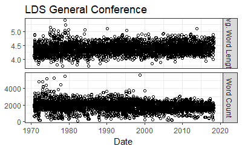

```r
tidy_conference_all <- conference_talks %>%
  filter(!str_detect(.$Title, pattern = "Church Officers|Statistical Report|Church Audit|Church Finance")) %>% # This does remove a few more talks than ideal, but it's pretty close
  mutate(Text = str_replace_all(Text, pattern = "[:digit:]|[:punct:]", replacement = " ")) %>%
  unnest_tokens(word, Text)
# Plotting the averages is not as interesting as seeing all of the points.
#tidy_conference_summary <- tidy_conference_all %>%
#  mutate(word_length = str_length(word)) %>%
#  group_by(Date, Title) %>%
#  #group_by(Title) %>%
#  summarise(word_count = n(), word_length = sum(word_length)) %>%
#  ungroup() %>%
#  drop_na() %>%
#  group_by(Date) %>%
#  summarise(`Average Words/Talk` = mean(word_count),
#            #`Median Words/Talk` = median(word_count),
#            word_count = sum(word_count),
#            sum_word_length = sum(word_length)) %>%
#  ungroup() %>%
#  mutate(Date = as.numeric(str_replace(Date, "-", ".")),
#         `Average Word Length` = sum_word_length/word_count) %>%
#  select(-sum_word_length, -word_count) %>%
#  gather(key = Type, value = Value, -Date)
#
#ggplot(tidy_conference_summary, aes(Date, Value)) +
#  geom_point() +
#  geom_smooth(method = "lm", se = FALSE) +
#  facet_grid(Type ~ ., scales = "free") +
#  theme_bw() +
#  theme(axis.title.y = element_blank()) +
#  ggtitle("LDS General Conference Averages")
#
#ggsave("General Conference Talk Word Count and Length.jpg", width = 7, height = 5, units = "in", dpi = 300)
# Summarize each conference talk by length and word length
tidy_conference_distr <- tidy_conference_all %>%
  mutate(word_length = str_length(word)) %>%
  group_by(Date, Title) %>%
  summarise(`Word Count` = n(), `Avg. Word Length` = mean(word_length)) %>%
  drop_na() %>%
  ungroup %>%
  gather(key = Key, value = Value, -Date, -Title) %>%
  mutate(Date = as.numeric(str_replace(Date, "-", ".")))
tidy_conference_distr %>%
  ggplot(aes(Date, Value)) +
  geom_jitter(width = .25, pch = 21) +
  facet_grid(Key ~ ., scales = "free") +
  theme_bw() +
  theme(axis.title.y = element_blank()) +
  ggtitle("LDS General Conference")
```

```r
#ggsave("General Conference Talk Word Count and Length Jitter.jpg", width = 7, height = 5, units = "in", dpi = 300)
```

What are the longest General Conference Talks?

```r
tidy_conference_distr %>%
  top_n(10, Value) %>%
  select(-Key) %>%
  rename(`Word Count` = Value) %>%
  dplyr::arrange(desc(`Word Count`))
```

| Date | Title | Word Count |
| --- | --- | --- |
| 1999.04 | Find the Lambs Feed the Sheep | 5633 |
| 1979.10 | The Administration of the Church | 5447 |
| 1976.04 | The Stone Cut without Hands | 5252 |
| 1974.04 | The Solemn Assembly | 5179 |
| 1972.10 | Admonitions for the Priesthood of God | 4813 |
| 1973.10 | President Harold B Lees General Priesthood Address | 4801 |
| 1978.10 | Privileges and Responsibilities of Sisters | 4476 |
| 1974.10 | The Davids and the Goliaths | 4414 |
| 1973.10 | Understanding Who We Are Brings Self-Respect | 4204 |
| 1973.10 | The Gospel of Jesus Christ Is the Golden Door | 4200 |

What talks have the longest average word length?

```r
tidy_conference_distr %>%
  filter(Key == "Avg. Word Length") %>%
  top_n(10, Value) %>%
  select(-Key) %>%
  rename(`Avg. Word Length` = Value) %>%
  dplyr::arrange(desc(`Avg. Word Length`))
```

| Date | Title | Avg. Word Length |
| --- | --- | --- |
| 1979.04 | Church Government through Councils | 5.394932 |
| 1979.04 | Developing Temporal Plans and Priorities | 5.226630 |
| 1975.10 | The Developing Welfare Services Department | 5.136741 |
| 2014.10 | Welcome to Conference | 5.105169 |
| 1990.10 | Redemption:The Harvest of Love | 5.097832 |
| 1984.10 | The Gospel and the Church | 5.061029 |
| 1976.04 | The Church Employment System | 5.052047 |
| 1980.04 | Priesthood Councils:Key to Meeting Temporal and Spiritual Needs | 5.048703 |
| 1975.10 | An Overview of Church Welfare Services | 5.046718 |
| 1995.10 | The Family:A Proclamation to the World | 5.034375 |

What are the longest words used in General Conference? Elder Ballard ended a 25 year tie for longest word in 2012 with the 22-charactor word “deinstitutionalization.”

```r
tidy_conference_all %>%
  mutate(`Word Length` = str_length(word)) %>%
  top_n(10, `Word Length`) %>%
  arrange(desc(`Word Length`)) %>%
  select(word, `Word Length`, Author, Title, Date)
```

| word | Word Length | Author | Title | Date |
| --- | --- | --- | --- | --- |
| deinstitutionalization | 22 | M. Russell Ballard | That the Lost May Be Found | 2012-04 |
| pseudosophistication | 20 | Dean L. Larsen | Looking beyond the Mark | 1987-10 |
| internationalization | 20 | N. Eldon Tanner | New Emphasis on Church Councils | 1979-04 |
| counterproductively | 19 | Virginia H. Pearce | The Ordinary Classrooma Powerful Place for Steady and Continued Growth | 1996-10 |
| repentancefollowing | 19 | George I. Cannon | TodayA Day of Eternity | 1991-10 |
| micromanifestations | 19 | Neal A. Maxwell | Yet Thou Art There | 1987-10 |
| incontrovertibility | 19 | Russell M. Nelson | Call to the Holy Apostleship | 1984-04 |
| interdenominational | 19 | Marvin J. Ashton | The Prophet and the Prison | 1980-04 |
| interresponsibility | 19 | Spencer W. Kimball | Keep the Lines of Communication Strong | 1972-04 |
| misrepresentations | 18 | Joy D. Jones | Value beyond Measure | 2017-10 |

[output cut: 13 more lines]

How has the sentiment of General Conference talks changed over time?

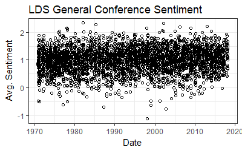

```r
tidy_conference_sentiment <- tidy_conference_all %>%
  inner_join(get_sentiments(lexicon = "afinn"), by = "word") %>%
  group_by(Date, Title, Author) %>%
  summarise(`Avg. Sentiment` = mean(score)) %>%
  ungroup() %>%
  mutate(Date = as.numeric(str_replace(Date, "-", ".")))
tidy_conference_sentiment %>%
  ggplot(aes(Date, `Avg. Sentiment`)) +
  geom_jitter(width = .25, pch = 21) +
  #geom_smooth() +
  #geom_hline(yintercept = c(.9, 1.1)) +
  theme_bw() +
  ggtitle("LDS General Conference Sentiment")
```

```r
NA
```

Which talks are the most positive?

```r
tidy_conference_sentiment %>%
  top_n(10, `Avg. Sentiment`) %>%
  arrange(desc(`Avg. Sentiment`))
```

| Date | Title | Author | Avg. Sentiment |
| --- | --- | --- | --- |
| 1982.04 | The Lord Is at the Helm | Spencer W. Kimball | 2.333333 |
| 2002.04 | Feel the Love of the Lord | Bonnie D. Parkin | 2.320000 |
| 1985.10 | In Response to the Call | M. Russell Ballard | 2.285714 |
| 2013.04 | Welcome to Conference | Thomas S. Monson | 2.214286 |
| 2006.10 | Closing Remarks | Gordon B. Hinckley | 2.192308 |
| 1998.04 | New Temples to Provide Crowning Blessings of the Gospel | Gordon B. Hinckley | 2.152542 |
| 1978.10 | Never Be Weary of Good Works | Jack H Goaslind Jr. | 2.139535 |
| 2009.10 | I Love Loud Boys | Yoon Hwan Choi | 2.139535 |
| 1978.04 | Everything Dear | Robert L. Backman | 2.133333 |
| 1978.04 | What Would the Savior Have Me Do | Derek A. Cuthbert | 2.086207 |

Which talks are the most negative?

```r
tidy_conference_sentiment %>%
  top_n(-10, `Avg. Sentiment`) %>%
  arrange(`Avg. Sentiment`)
```

| Date | Title | Author | Avg. Sentiment |
| --- | --- | --- | --- |
| 1998.04 | Agency and Anger | Lynn G. Robbins | -1.1176471 |
| 2003.04 | Forgiveness Will Change Bitterness to Love | David E. Sorensen | -0.7548387 |
| 1987.10 | Balm of Gilead | Boyd K. Packer | -0.6910112 |
| 1999.10 | Spiritual Hurricanes | David R. Stone | -0.6261682 |
| 1977.10 | The Balm of Gilead | Boyd K. Packer | -0.6132597 |
| 1978.10 | The Last Words of Moroni | Mark E. Petersen | -0.5068493 |
| 1971.10 | Honesty a Principle of Salvation | Mark E. Petersen | -0.4918033 |
| 1971.04 | Be Slow to Anger | ElRay L. Christiansen | -0.4745763 |
| 1999.04 | Repent of Our Selfishness DC 56:8 | Neal A. Maxwell | -0.4698795 |
| 2001.04 | The Touch of the Masters Hand | Boyd K. Packer | -0.4659686 |

How many unique words are used in General Conference?

```r
tidy_conference_all %>%
  select(word) %>%
  unique() %>%
  nrow()
```

```
[1] 38045
```

What are the most comon words once the “Stop words” have been removed?

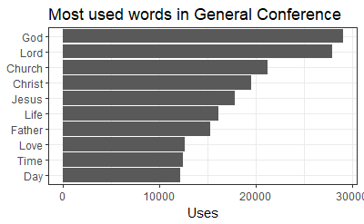

```r
tidy_conference_all %>%
  anti_join(stop_words, by = "word") %>%
  group_by(word) %>%
  summarise(n = n()) %>%
  top_n(10, n) %>%
  arrange(desc(n)) %>%
  mutate(word = reorder(str_to_title(word), n)) %>%
  select(Word = word, Uses = n) %>%
  ggplot(aes(x = Word, y = Uses)) +
  geom_col() +
  xlab(NULL) +
  coord_flip() +
  theme_bw() +
  ggtitle("Most used words in General Conference")
```

```r
#ggsave("General Conference Most Used Words.jpg", width = 7, height = 5, units = "in", dpi = 300)
```

What are some unique words that stand out over time from General Conference?

```r
tidy_conference_all %>%
  anti_join(tibble(word = c("ne", "vol", "pp", "italics", "ibid", "km", "moro", "isa", "cor", "vv", "gen", "js", "eph", "cr", "heb", "ps", "hel", "rev")), by = "word") %>%
  mutate(Year = floor(as.numeric(str_trunc(Date, 4, side = "right", ellipsis = ""))/10)*10) %>%
  count(Year, word, sort = TRUE) %>%
  bind_tf_idf(word, Year, n) %>%
  group_by(Year) %>%
  top_n(10, tf_idf) %>%
  arrange(desc(tf_idf))
```

| Year | word | n | tf | idf | tf_idf |
| --- | --- | --- | --- | --- | --- |
| 2010 | internet | 87 | 7.939825e-05 | 0.5108256 | 4.055866e-05 |
| 2000 | internet | 100 | 7.616517e-05 | 0.5108256 | 3.890712e-05 |
| 2010 | gong | 26 | 2.372821e-05 | 1.6094379 | 3.818909e-05 |
| 2010 | eva | 45 | 4.106806e-05 | 0.9162907 | 3.763028e-05 |
| 2010 | org | 40 | 3.650494e-05 | 0.9162907 | 3.344914e-05 |
| 2000 | patton | 25 | 1.904129e-05 | 1.6094379 | 3.064578e-05 |
| 1990 | bookcraft | 71 | 5.166894e-05 | 0.5108256 | 2.639382e-05 |
| 2010 | bednar | 31 | 2.829133e-05 | 0.9162907 | 2.592308e-05 |
| 1980 | bookcraft | 60 | 4.677433e-05 | 0.5108256 | 2.389352e-05 |
| 2010 | cowan | 16 | 1.460198e-05 | 1.6094379 | 2.350098e-05 |

[output cut: 41 more lines]

How do the tl-df words of the three most recent LDS Presidents compare?

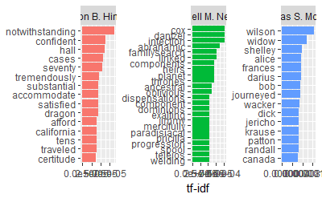

```r
gc_presidents_tl_df <- tidy_conference_all %>%
  filter(Author %in% c("Gordon B. Hinckley", "Thomas S. Monson", "Russell M. Nelson")) %>%
  count(Author, word, sort = TRUE) %>%
  bind_tf_idf(word, Author, n) %>%
  arrange(desc(tf_idf)) %>%
  mutate(word = factor(word, levels = rev(unique(word)))) %>%
  group_by(Author) %>%
  top_n(15, tf_idf) %>%
  ungroup %>%
  mutate(Author = as.factor(Author))
ggplot(gc_presidents_tl_df, aes(word, tf_idf, fill = Author)) +
  geom_col(show.legend = FALSE) +
  labs(x = NULL, y = "tf-idf") +
  facet_wrap(~Author, scales = "free") +
  coord_flip()
```

```r
gc_presidents_tl_df
```

| Author | word | n | tf | idf | tf_idf |
| --- | --- | --- | --- | --- | --- |
| Thomas S. Monson | wilson | 48 | 1.141664e-04 | 1.0986123 | 1.254246e-04 |
| Russell M. Nelson | cox | 13 | 9.367411e-05 | 1.0986123 | 1.029115e-04 |
| Russell M. Nelson | dantzel | 13 | 9.367411e-05 | 1.0986123 | 1.029115e-04 |
| Russell M. Nelson | infection | 13 | 9.367411e-05 | 1.0986123 | 1.029115e-04 |
| Thomas S. Monson | widow | 101 | 2.402251e-04 | 0.4054651 | 9.740290e-05 |
| Gordon B. Hinckley | notwithstanding | 35 | 7.990120e-05 | 1.0986123 | 8.778044e-05 |
| Russell M. Nelson | abrahamic | 11 | 7.926271e-05 | 1.0986123 | 8.707899e-05 |
| Russell M. Nelson | familysearch | 10 | 7.205701e-05 | 1.0986123 | 7.916272e-05 |
| Russell M. Nelson | linked | 10 | 7.205701e-05 | 1.0986123 | 7.916272e-05 |
| Thomas S. Monson | shelley | 30 | 7.135399e-05 | 1.0986123 | 7.839037e-05 |

[output cut: 44 more lines]

How to the favorit words of the three most recent LDS Presidents compare?

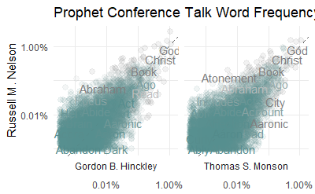

```r
tidy_conference_all %>%
  filter(Author %in% c("Gordon B. Hinckley", "Thomas S. Monson", "Russell M. Nelson")) %>%
  anti_join(stop_words, by = "word") %>%
  mutate(word = str_to_title(word)) %>%
  count(Author, word) %>%
  group_by(Author) %>%
  mutate(proportion = n / sum(n)) %>%
  select(-n) %>%
  spread(Author, proportion) %>%
  gather(Author, proportion, -`Russell M. Nelson`, -word) %>%
  drop_na() %>%
  ggplot(aes(x = proportion, y = `Russell M. Nelson`, color = abs(`Russell M. Nelson` - proportion))) +
  geom_abline(color = "gray40", lty = 2) +
  geom_jitter(alpha = 0.1, size = 2.5, width = 0.3, height = 0.3) +
  geom_text(aes(label = word), check_overlap = TRUE, vjust = 1.5) +
  scale_x_log10(labels = percent_format()) +
  scale_y_log10(labels = percent_format()) +
  scale_color_gradient(limits = c(0, 0.001), low = "darkslategray4", high = "gray75") +
  facet_wrap(~Author, ncol = 2, strip.position = "bottom") +
  labs(y = "Russell M. Nelson", x = NULL) +
  ggtitle("Prophet Conference Talk Word Frequency") +
  theme_minimal() +
  theme(legend.position="none")
```

```r
#ggsave("General Conference Talk Word Frequency by Prophet.jpg", width = 7, height = 5, units = "in", dpi = 300)
```

What phrases tend to go together?

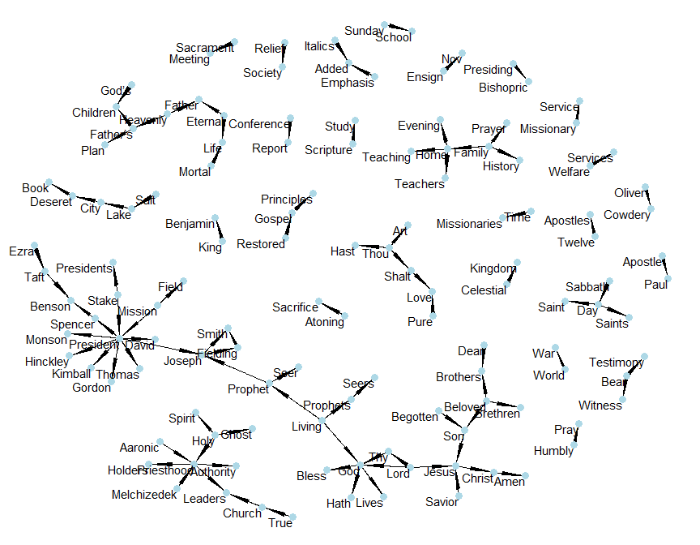